# Human Genome Analysis Lab 11 : Analysis and visualization of your SNP data - Part 2

### Genomic localization of SNPs with GGBIO

ggbio is a Bioconductor package building on top of ggplot2. It provides a genomic visualization framework that facilitates graphing of SNP, RNAseq and other data in a genome context. ’ggbio` is available through Bioconductor https://bioconductor.org/packages/release/bioc/html/ggbio.html . There is a brand new tutorial (Nov 1) that could be used to build on the below example visualizations.

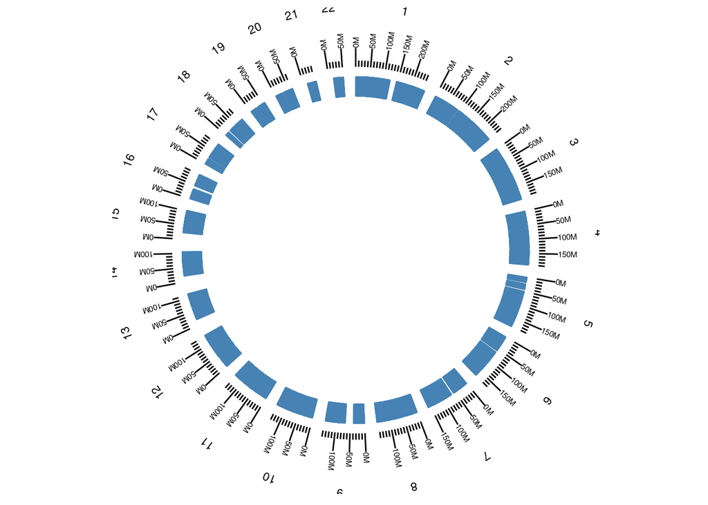

```r
mySNPs_gwas_table_1_22 <- mySNPs_gwas_table %>%
  filter(seqnames %in% 1:22 & have_risk_allele_count > 1) %>%
  distinct(rsid, .keep_all = TRUE)

mySNPs_gwas_plot_1_22 <- GRanges(seqnames = mySNPs_gwas_table_1_22$seqnames, ranges = mySNPs_gwas_table_1_22$start, seqlengths = seqlengths(hg19sub), seqinfo = seqinfo(hg19sub))

ggbio()  +
  circle(mySNPs_gwas_plot_1_22, geom = "rect", color = "steelblue") +
  circle(hg19sub, geom = "scale", size = 2) +
  circle(hg19sub, geom = "text", aes(label = seqnames), vjust = -2, size = 3)
```

#### Visualization of disease the genome location of disease specific alleles

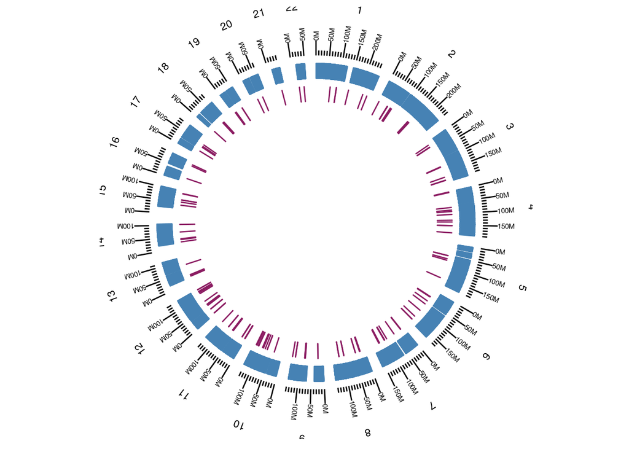

```r
mySNPs_gwas_table_disease <- mySNPs_gwas_table %>%
  filter(seqnames %in% 1:22 & have_risk_allele_count > 1 & DISEASE.TRAIT == "Type 2 diabetes") %>%
  distinct(rsid, .keep_all = TRUE)

mySNPs_gwas_plot_disease <- GRanges(seqnames = mySNPs_gwas_table_disease$seqnames, ranges = mySNPs_gwas_table_disease$start, seqlengths = seqlengths(hg19sub), seqinfo = seqinfo(hg19sub))

ggbio()  +
  circle(mySNPs_gwas_plot_disease, geom = "rect", color = "maroon4") +
  circle(mySNPs_gwas_plot_1_22, geom = "rect", color = "steelblue") +
  circle(hg19sub, geom = "scale", size = 2) +
  circle(hg19sub, geom = "text", aes(label = seqnames), vjust = -2, size = 3)
```

## Excercises

### Excercise 1

Create a Manhattan plot using a different disease trait.

### Excercise 2

Using ggbio map a disease alleles to a circularized human genome.

### Excercise 3

Make a graph using another aspect of the GWAS data.

### Bonus

Identify whether you have in your data set any of the alleles identified in the Hugo Zeberg and Svante Pääbo PNAS articles. You can simply enter the RSIDs and use `filter` as in the earlier Part 1 to this lab.

## Acknowledgements

Special thanks to former MCB student Dr. Kirk MacKinnon for ideas of further using the GWASCAT data and visualizaitions.